# Local Adaptation and Range Expansion in Culex Mosquitoes

### Samantha Taylor, Lindsay Shields, Touhid Islam, Jade Takakuwa, and Elizabeth Cooper

#### 2021 - 2022 Academic Year

## Introduction

*Culex tarsalis*, (also known as the Western Encephalitis Mosquito) is a North American mosquito species known for being the principal vector of the West Nile virus along with other arboviruses. This mosquito primarily inhabits the western U.S. and comprises of three genetically distinct genetic population clusters: the Pacific, Sonoran, and Midwest clusters. Due to *Cx. tarsalis* mosquitoes carrying dangerous diseases that infect both birds and livestock animals, questions arise pertaining to the possibility of them continuing to spread east of the Mississippi. Therefore, for this project, we will be examining:

1. What environmental factors drive local adaptation and genetic divergence in different populations of Culex?  
2. Can we predict the spread of Culex in the near future to better inform management practices to mitigate disease risks?

[figure not shown]

```python
import pandas as pd
import numpy as np
```

## Part One of This Project: The Reference Genome

For this project, the first genome assembly of *Cx. tarsalis* by the UC Davis DNA Technologies Core [[1]](https://academic.oup.com/g3journal/article/11/2/jkaa063/6080661) from the Kern National Wildlife Refuge colony was used as the reference genome. Their team conducted a PacBio genome assembly, sequenced two Nextera libraries (Illumina), and used two pupae for 10X library preparation. To analyze and further investigate this genome, for the purposes of this project, we:

- Masked the genome with MaskFasta to improve alignment  
- Determining reference genome mappability with GenMap  
- Found orthogroups and gene duplication events with OrthoFinder  
- Conducted gene ontology analysis with topGO  
- Collected protein function predictive information with InterProScan  
- Assigned orthogroups IDs to functional descriptions  
- Used Natural Language Processing via UniFunc to simplify protein function annotations

### Reference Genome Masking With MaskFasta To Improve Alignment

Due to some parts of the genome being repeat-heavy regions, the creators of the reference genome used the Repeat Masker program [[2]](https://www.animalgenome.org/bioinfo/resources/manuals/RepeatMasker.html) and a custom repeat library to annotate 60.8% of the genome as a repeat feature. A gff3 file was created of the repeated regions, which was modified for use during the bedtools maskfasta step.

Bedtools utilities [[3]](https://bedtools.readthedocs.io/en/latest/) allow for the intersection, merging, counting, complementing, and shuffling of genomic intervals from multiple files in file formats such as BAM, BED, GFF/GTF, and VCF. Bedtools V2.29.0 was used.

For the purposes of this project, the bedtools maskfasta utility was used to mask FASTA file sequences using the reference genome fasta and complementary gff3 file. The repeat masker features in the previously made gff3 were used to create a masked reference genome, which annotated 60.843% of the genome as repeat features.

```python
%%script bash --bg

module load bedtools2

bedtools maskfasta -fi Culex-tarsalis_knwr_CONTIGS_CtarK1.fa -bed RM_only-Culex-tarsalis_knwr_BASEFEATURES_CtarK1.gff3 -fo Masked-Culex-tarsalis_knwr_CONTIGS_CtarK1.fa -mc X
```

### Determining Reference Genome Mappability With GenMap

Due to the continuation of poor coverage, poor quality data, GenMap [[4]](https://github.com/cpockrandt/genmap#bioconda) was used on the C. tarsalis reference genome to compute mappability; essencially, to see if sections of the genome were unable to be mapped to. The genome was indexed, and (150,2) mappability was computed. Text, wig and bedGraph files were created as output. A mappability value of 1 at position i indicates the k-mer in the sequence at position 1 occurs only once in the reference sequence. A mappability value of 0.5, implies it occurs twice in the sequence. The lower the mappability value, the more repetitive the region. Genmap V1.3.0 was used.

```python
%%script bash --bg

$ ./genmap index -F Culex-tarsalis_knwr_CONTIGS_CtarK1.fa -I ./genmapculex
$ ./genmap map -K 150 -E 2 -I ./genmapculex -O ./mappability -t -w -bg

$ ./genmap index -F Masked-Culex-tarsalis_knwr_CONTIGS_CtarK1.fa -I ./Mgenmapculex
$ ./genmap map -K 150 -E 2 -I ./Mgenmapculex -O ./Mmappability -t -w -bg
```

#### Mappability Analysis Pre-Masking

Total read count = 1316238

Counts

Percentages

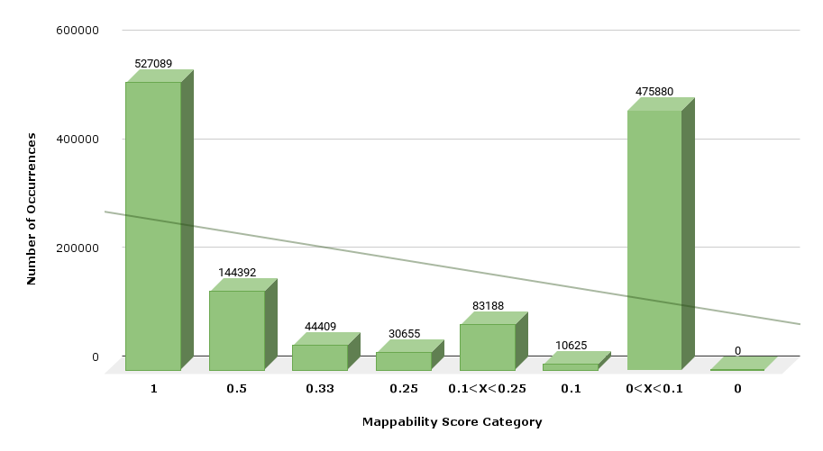

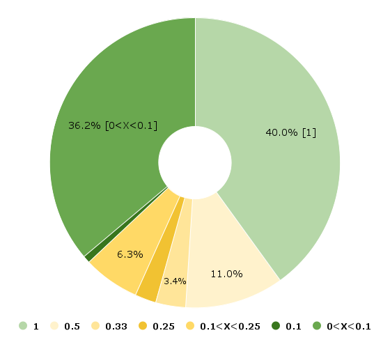

#### Mappability Analysis Post-Masking

Total read count = 62965

Counts

Percentages

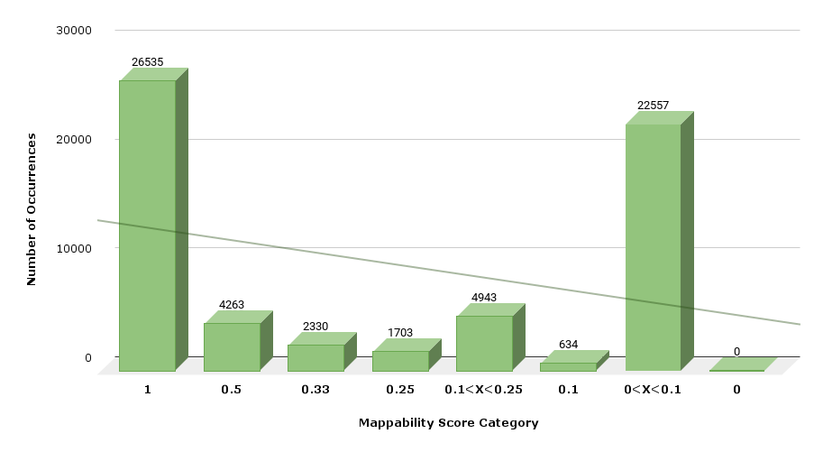

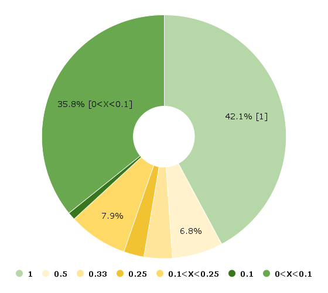

### Orthogroups and Phylogenetic Inferences With OrthoFinder

In order to calculate comparative genomics, OrthoFinder [[5]](https://genomebiology.biomedcentral.com/articles/10.1186/s13059-019-1832-y) was used to find orthogroups, orthologs, rooted gene/species trees, and gene duplication events. For the purposes of this project, information on which protein accessions were in which orthogroup was collected, species trees were examined using Dendroscope [[6]](https://academic.oup.com/sysbio/article/61/6/1061/1666897), and gene duplications events were analized. OrthoFinder V2.4.0 and Dendroscope V3.8.3 were used.

```python
%%script bash --bg

module load orthofinder

orthofinder -f ./MosProteinFASTAsFolder
```

#### Rooted Species Tree With Node Labels

A STAG (Species Tree inference from All Genes) species tree concluded from all orthogroups, containing nodes given labels (instead of support values) to allow other results files to cross-reference branches/nodes in the species tree (e.g. location of gene duplication events).

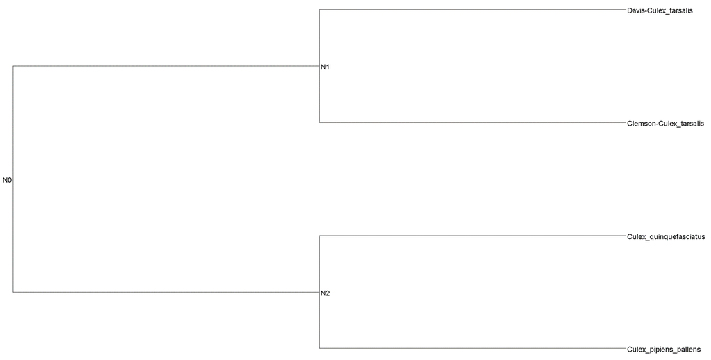

#### Species Tree Gene Duplications With At Least 50% Support

A summation of identified duplications over the branches of the species tree. It is a text file in newick format. The numbers after each node or species name are the number of gene duplication events with at least 50% support that occurred on the branch leading to the node/species. The branch lengths are the standard branch lengths, as give in Species_Tree/SpeciesTree_rooted.txt.

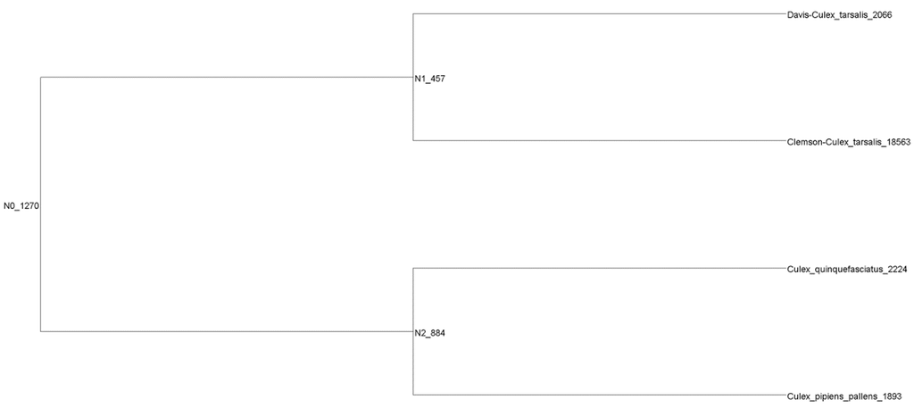

```python
Orthogroups = pd.read_csv("Orthogroups.tsv",sep='\t')
Orthogroups = Orthogroups.fillna('')
Orthogroups.head()
```

|  | Orthogroup | Clemson_tarsalis | Culex_quinquefasciatus | Davis_tarsalis | Culex_pipiens |
| --- | --- | --- | --- | --- | --- |
| 0 | OG0000000 | Clemson_tarsalis_Ct.00g000390.m01, Clemson_tar... | Culex_quinquefasciatus_CPIJ003782-PA, Culex_qu... | Davis_tarsalis_mRNA6969, Davis_tarsalis_mRNA8820 | Culex_pipiens_00000508-RA, Culex_pipiens_00014... |
| 1 | OG0000001 | Clemson_tarsalis_Ct.00g000420.m01, Clemson_tar... | Culex_quinquefasciatus_CPIJ005359-PA, Culex_qu... | Davis_tarsalis_mRNA14890 | Culex_pipiens_00001767-RA, Culex_pipiens_00002... |
| 2 | OG0000002 | Clemson_tarsalis_Ct.00g000220.m01, Clemson_tar... | Culex_quinquefasciatus_CPIJ014099-PA | Davis_tarsalis_mRNA8910, Davis_tarsalis_mRNA9390 | Culex_pipiens_00004994-RA |
| 3 | OG0000003 | Clemson_tarsalis_Ct.00g000010.m01, Clemson_tar... | Culex_quinquefasciatus_CPIJ010419-PA, Culex_qu... |  | Culex_pipiens_00007914-RA |
| 4 | OG0000004 | Clemson_tarsalis_Ct.00g003100.m01, Clemson_tar... | Culex_quinquefasciatus_CPIJ001417-PA, Culex_qu... |  | Culex_pipiens_00002767-RA, Culex_pipiens_00006... |

### Comparative Genomics Statistics With OrthoFinder - Duplication Events

OrthoFinder [[15]](https://github.com/davidemms/OrthoFinder/blob/master/README.md) provides comparative genomic analyses through comprehensive statistics.

#### Duplications per Orthogroup

A tab delimited text file that provides the amount of duplications found in each orthogroup.

```python
Duplications_per_Orthogroup = pd.read_csv("Duplications_per_Orthogroup.tsv",sep='\t')#,index_col=0)
Duplications_per_Orthogroup.sort_values(by="Duplications (all)",ascending=False,inplace=True)
Duplications_per_Orthogroup.head()
```

|  | Orthogroup | Duplications (all) | Duplications (50% support) |
| --- | --- | --- | --- |
| 0 | OG0000000 | 882 | 874 |
| 1 | OG0000001 | 711 | 694 |
| 2 | OG0000002 | 403 | 403 |
| 3 | OG0000003 | 373 | 364 |
| 4 | OG0000004 | 352 | 347 |

#### Duplications per Species Tree Node

A tab delimited text file that provides the number of duplications identified as occurring along each branch of the species tree.

For the purposes of this project, species tree nodes **Clemson-Culex_tarsalis, Davis-Culex_tarsalis, and N1** are being scrutinized the most.

```python
Duplications_per_Species_Tree_Node = pd.read_csv("Duplications_per_Species_Tree_Node.tsv",sep='\t',index_col=0)
Duplications_per_Species_Tree_Node
```

| Species Tree Node | Duplications (all) | Duplications (50% support) |
| --- | --- | --- |
| Clemson-Culex_tarsalis | 18563 | 18563 |
| Davis-Culex_tarsalis | 2066 | 2066 |
| Culex_quinquefasciatus | 2224 | 2224 |
| Culex_pipiens_pallens | 1893 | 1893 |
| N0 | 1705 | 1270 |
| N1 | 457 | 457 |
| N2 | 884 | 884 |

#### Matching Orthogroups to Gene Ontology Terms

Tab delimited files containing all orthogroup information that was linked to a GO term were created for the purpose of running the final file through topGO.

```python
%%script sqlite3 --bg
SELECT Orthogroups.Orthogroup, AllGOInterProOutput.GO_Term
FROM Orthogroups, AllGOInterProOutput
WHERE Orthogroups.Clemson_tarsalis LIKE AllGOInterProOutput.Protein accession OR
Orthogroups.Culex_quinquefasciatus LIKE AllGOInterProOutput.Protein accession OR
Orthogroups.Davis_tarsalis LIKE AllGOInterProOutput.Protein accession OR
Orthogroups.Culex_pipiens LIKE AllGOInterProOutput.Protein accession

# export as OG2GO.csv
```

```python
%%script sqlite3 --bg
DELETE FROM OG2GO
WHERE OG2GO.GO_Term IS NULL OR trim(OG2GO.GO_Term) = ''
OR trim(OG2GO.GO_Term) = '-';

UPDATE OG2GO
SET GO_Term = REPLACE(OG2GO.GO_Term,'|',',')

SELECT DISTINCT OG2GO.Orthogroup, OG2GO.GO_Term
FROM OG2GO
ORDER BY OG2GO.Orthogroup;

# export as OG2GO_2.csv
```

```python
OG2GO = pd.read_csv("OG2GO_2.csv",sep='\t', index_col=False)
OG2GO_2 = OG2GO.groupby(['Orthogroup']).agg({'GO_Term': ','.join})
OG2GO_2 = OG2GO_2.reset_index(drop=False)
OG2GO_2.head()

OG2GO_2.to_csv('OG2GO_3.tsv',index=False, sep='\t')
```

|  | Orthogroup | GO_Term |
| --- | --- | --- |
| 0 | OG0000002 | GO:0004329,GO:0005524,GO:0004488,GO:0005524,GO... |
| 1 | OG0000018 | GO:0015074 |
| 2 | OG0000027 | GO:0003677 |
| 3 | OG0000040 | GO:0005515 |
| 4 | OG0000055 | GO:0000786,GO:0003677,GO:0006334,GO:0000786,GO... |

#### Gene Duplication Events - All

A tab delimited file containing all gene duplication events found through examination of each node of each orthogroup gene tree. This file identifies what duplications are in which orthogroups are on what species node, and which genes are involved in the duplication.

```python
Duplications = pd.read_csv("Duplications.tsv",sep='\t', index_col=False)
Duplications = Duplications.fillna('')
Duplications.head()
```

|  | Orthogroup | Species Tree Node | Gene Tree Node | Support | Type | Genes 1 | Genes 2 |
| --- | --- | --- | --- | --- | --- | --- | --- |
| 0 | OG0000000 | N0 | n0 | 1.00 | Non-Terminal | Culex_pipiens_pallens_Culex_pipiens_00000508-R... | Culex_pipiens_pallens_Culex_pipiens_00014874-R... |
| 1 | OG0000000 | N0 | n5 | 0.25 | Non-Terminal | Clemson-Culex_tarsalis_Ct*00g148070*m01 | Clemson-Culex_tarsalis_Ct*00g043020*m01, Clems... |
| 2 | OG0000000 | N0 | n6 | 0.25 | Non-Terminal | Clemson-Culex_tarsalis_Ct*00g043020*m01 | Clemson-Culex_tarsalis_Ct*00g256210*m01, Clems... |
| 3 | OG0000000 | N0 | n7 | 0.25 | Non-Terminal | Clemson-Culex_tarsalis_Ct*00g256210*m01, Clems... | Clemson-Culex_tarsalis_Ct*00g188270*m01, Clems... |
| 4 | OG0000000 | Clemson-Culex_tarsalis | n8 | 1.00 | Terminal | Clemson-Culex_tarsalis_Ct*00g256210*m01, Clems... | Clemson-Culex_tarsalis_Ct*00g152390*m01, Clems... |

#### Gene Duplication Events - N1 Node

A dataframe containing all rows pertaining to the *Culex tarsalis* specific node.

```python
N1_Duplications = Duplications[Duplications["Species Tree Node"] == "N1"]
N1_Duplications_ADJ = N1_Duplications[['Orthogroup', 'Species Tree Node']].copy()
N1_Duplications_ADJ2 = N1_Duplications_ADJ.groupby(N1_Duplications_ADJ.columns.tolist()).size().\
        reset_index(drop=False).rename(columns={0:'Replicates'})
N1_Duplications_ADJ2.head()

DupN1OG = N1_Duplications_ADJ2['Orthogroup'].copy()
DupN1OG.to_csv('DupN1OG.csv',index=False, sep='\t')
```

|  | Orthogroup | Species Tree Node | Replicates |
| --- | --- | --- | --- |
| 0 | OG0000002 | N1 | 3 |
| 1 | OG0000030 | N1 | 3 |
| 2 | OG0000050 | N1 | 1 |
| 3 | OG0000051 | N1 | 3 |
| 4 | OG0000055 | N1 | 4 |

```python
%%script sqlite3 --bg
SELECT OG2GO_3.Orthogroup
FROM DupN1OG, OG2GO_3
WHERE OG2GO_3.Orthogroup == DupN1OG.Orthogroup

# export as SigDupN1OG
```

#### Gene Duplication Events - Culex tarsalis (Clemson) Node

A dataframe containing all rows pertaining to the *Clemson-Culex_tarsalis* specific species node to find duplication events specifically related to the Clemson reference genome.

```python
Clemson_Duplications = Duplications[Duplications["Species Tree Node"] == "Clemson-Culex_tarsalis"]
Clemson_Duplications_ADJ = Clemson_Duplications[['Orthogroup', 'Species Tree Node']].copy()

Clemson_Duplications_ADJ2 = Clemson_Duplications_ADJ.groupby(Clemson_Duplications_ADJ.columns.tolist()).size().\
        reset_index(drop=False).rename(columns={0:'Replicates'})
Clemson_Duplications_ADJ2.head()

DupClemsonOG = Clemson_Duplications_ADJ2['Orthogroup'].copy()
DupClemsonOG.to_csv('DupClemsonOG.csv',index=False, sep='\t')
```

|  | Orthogroup | Species Tree Node | Replicates |
| --- | --- | --- | --- |
| 0 | OG0000000 | Clemson-Culex_tarsalis | 871 |
| 1 | OG0000001 | Clemson-Culex_tarsalis | 685 |
| 2 | OG0000002 | Clemson-Culex_tarsalis | 400 |
| 3 | OG0000003 | Clemson-Culex_tarsalis | 362 |
| 4 | OG0000004 | Clemson-Culex_tarsalis | 341 |

```python
%%script sqlite3 --bg
SELECT OG2GO_3.Orthogroup
FROM DupClemsonOG, OG2GO_3
WHERE OG2GO_3.Orthogroup == DupClemsonOG.Orthogroup

# export as SigDupClemsonOG
```

#### Gene Duplication Events - Culex tarsalis (UC Davis) Node

A dataframe containing all rows pertaining to the *Davis-Culex_tarsalis* specific species node to find duplication events specifically related to the UC Davis reference genome.

```python
Davis_Duplications = Duplications[Duplications["Species Tree Node"] == "Davis-Culex_tarsalis"]
Davis_Duplications_ADJ = Davis_Duplications[['Orthogroup', 'Species Tree Node']].copy()

Davis_Duplications_ADJ2 = Davis_Duplications_ADJ.groupby(Davis_Duplications_ADJ.columns.tolist()).size().\
        reset_index(drop=False).rename(columns={0:'Replicates'})
Davis_Duplications_ADJ2.head()

DupDavisOG = Davis_Duplications_ADJ2['Orthogroup'].copy()
DupDavisOG.to_csv('DupDavisOG.csv',index=False, sep='\t')
```

|  | Orthogroup | Species Tree Node | Replicates |
| --- | --- | --- | --- |
| 0 | OG0000037 | Davis-Culex_tarsalis | 5 |
| 1 | OG0000050 | Davis-Culex_tarsalis | 1 |
| 2 | OG0000051 | Davis-Culex_tarsalis | 2 |
| 3 | OG0000072 | Davis-Culex_tarsalis | 4 |
| 4 | OG0000085 | Davis-Culex_tarsalis | 4 |

```python
%%script sqlite3 --bg
SELECT OG2GO_3.Orthogroup
FROM DupDavisOG, OG2GO_3
WHERE OG2GO_3.Orthogroup == DupDavisOG.Orthogroup

# export as SigDupDavisOG
```

#### Gene Duplication Events - Culex quinquefasciatus Node

```python
Quinque_Duplications = Duplications[Duplications["Species Tree Node"] == "Culex_quinquefasciatus"]
Quinque_Duplications_ADJ = Quinque_Duplications[['Orthogroup', 'Species Tree Node']].copy()

Quinque_Duplications_ADJ2 = Quinque_Duplications_ADJ.groupby(Quinque_Duplications_ADJ.columns.tolist()).size().\
        reset_index(drop=False).rename(columns={0:'Replicates'})
Quinque_Duplications_ADJ2.head()

DupQuinqueOG = Quinque_Duplications_ADJ2['Orthogroup'].copy()
DupQuinqueOG.to_csv('DupQuinqueOG.csv',index=False, sep='\t')
```

|  | Orthogroup | Species Tree Node | Replicates |
| --- | --- | --- | --- |
| 0 | OG0000004 | Culex_quinquefasciatus | 1 |
| 1 | OG0000028 | Culex_quinquefasciatus | 10 |
| 2 | OG0000029 | Culex_quinquefasciatus | 3 |
| 3 | OG0000030 | Culex_quinquefasciatus | 2 |
| 4 | OG0000037 | Culex_quinquefasciatus | 4 |

```python
%%script sqlite3 --bg
SELECT OG2GO_3.Orthogroup
FROM DupQuinqueOG, OG2GO_3
WHERE OG2GO_3.Orthogroup == DupQuinqueOG.Orthogroup

# export as SigDupQuinqueOG
```

#### Gene Duplication Events - Culex pipiens pallens Node

```python
Pipien_Duplications = Duplications[Duplications["Species Tree Node"] == "Culex_pipiens_pallens"]
Pipien_Duplications_ADJ = Pipien_Duplications[['Orthogroup', 'Species Tree Node']].copy()

Pipien_Duplications_ADJ2 = Pipien_Duplications_ADJ.groupby(Pipien_Duplications_ADJ.columns.tolist()).size().\
        reset_index(drop=False).rename(columns={0:'Replicates'})
Pipien_Duplications_ADJ2.head()

DupPipienOG = Pipien_Duplications_ADJ2['Orthogroup'].copy()
DupPipienOG.to_csv('DupPipienOG.csv',index=False, sep='\t')
```

|  | Orthogroup | Species Tree Node | Replicates |
| --- | --- | --- | --- |
| 0 | OG0000001 | Culex_pipiens_pallens | 2 |
| 1 | OG0000030 | Culex_pipiens_pallens | 1 |
| 2 | OG0000050 | Culex_pipiens_pallens | 1 |
| 3 | OG0000051 | Culex_pipiens_pallens | 4 |
| 4 | OG0000072 | Culex_pipiens_pallens | 1 |

```python
%%script sqlite3 --bg
SELECT OG2GO_3.Orthogroup
FROM DupPipienOG, OG2GO_3
WHERE OG2GO_3.Orthogroup == DupPipienOG.Orthogroup

# export as SigDupPipienOG
```

### Getting Protein Function Predictive Information With InterProScan

In order to match protein accessions with functional descriptions, InterProScan [[7]](https://doi.org/10.1093/nar/gki442) was used to collect protein functional and predictive information.

```python
%%script bash --bg
module load interproscan

interproscan.sh -cpu 16 -goterms -i Quinquefasciatus.proteins.fasta -dp -b ./Culex_quinquefasciatus__GOInterProOutput
interproscan.sh -cpu 16 -goterms -i Pipiens.proteins.fasta -dp -b ./Culex_pipiens_pallens__GOInterProOutput
interproscan.sh -cpu 16 -goterms -i Davis_tarsalis.proteins.fasta -dp -b ./Davis-Culex_tarsalis__GOInterProOutput
interproscan.sh -cpu 16 -goterms -i Clemson_tarsalis.proteins.fasta -dp -b ./Clemson-Culex_tarsalis__GOInterProOutput

cat *__GOInterProOutput.tsv > AllGOInterProOutput.tsv
```

```python
AllGOInterProOutput = pd.read_csv("AllGOInterProOutput.tsv",sep='\t')
AllGOInterProOutput = AllGOInterProOutput.fillna('')
AllGOInterProOutput.head()
```

|  | Protein accession | Sequence MD5 digest | Sequence length | Analysis | Signature accession | Signature description | Start location | Stop location | Score | Status | Date | InterPro annotations - accession | InterPro annotations - description | GO_Term |
| --- | --- | --- | --- | --- | --- | --- | --- | --- | --- | --- | --- | --- | --- | --- |
| 0 | Clemson_tarsalis_Ct.00g268710.m01.polypeptide | a2898e6bb199d565e512004fa664eab7 | 1463 | CDD | cd01479 | Sec24-like | 690 | 938 | 3.45499E-116 | T | 14-06-2022 | IPR041742 | Sec24-like, trunk domain | GO:0006886\|GO:0006888\|GO:0030127 |
| 1 | Clemson_tarsalis_Ct.00g380650.m01.polypeptide | 0a4dfc668b760d2e62d7f5c53f875d31 | 116 | MobiDBLite | mobidb-lite | consensus disorder prediction | 101 | 116 | - | T | 14-06-2022 | - | - |  |
| 2 | Clemson_tarsalis_Ct.00g380650.m01.polypeptide | 0a4dfc668b760d2e62d7f5c53f875d31 | 116 | MobiDBLite | mobidb-lite | consensus disorder prediction | 90 | 116 | - | T | 14-06-2022 | - | - |  |
| 3 | Clemson_tarsalis_Ct.00g389150.m01.polypeptide | a9e36bff72224f086de97d827976074d | 1038 | MobiDBLite | mobidb-lite | consensus disorder prediction | 970 | 1000 | - | T | 14-06-2022 | - | - |  |
| 4 | Clemson_tarsalis_Ct.00g389150.m01.polypeptide | a9e36bff72224f086de97d827976074d | 1038 | MobiDBLite | mobidb-lite | consensus disorder prediction | 859 | 874 | - | T | 14-06-2022 | - | - |  |

```python
%%script sqlite3 --bg
SELECT Orthogroups.Orthogroup, Mosquito."Protein accession", Mosquito.Score,
Mosquito."Signature description", Mosquito."InterPro annotations - description”
FROM Orthogroups, Mosquito
WHERE Orthogroups.Mosquito LIKE Mosquito."Protein accession"
# export as OGMosquito.txt
```

Next, the 'OGMosquito' table created previously was analyzed, and was removed of duplicates. A new table was created for each mosquito species, 'OutOGMosquito'.

```python
%%script sqlite3 --bg
DELETE FROM OGMosquito
WHERE EXISTS (
SELECT 1 FROM OGMosquito p2
WHERE OGMosquito.Column1 = p2.Column1
AND OGMosquito.Column2 = p2.Column2
AND OGMosquito.Column4 = p2.Column4
AND OGMosquito.rowid > p2.rowid
);
SELECT * FROM OGMosquito
# export as OutOGMosquito.txt
```

Finally, each of the 4 Culex species tables were combined into 1, table 'OutOGAll.txt'.

```python
%%script bash --bg
cat OutOGMosquito1.txt OutOGMosquito2.txt OutOGMosquito3.txt OutOGMosquito4.txt >> OutOGAll.txt
```

```python
OutOGAll = pd.read_csv("OutOGAll.txt",sep='\t')
OutOGAll = OutOGAll.fillna('')
OutOGAll.tail()
```

### Using Natural Language Processing (UniFunc) To Simplify Functional Descriptions

In order to link orthogroups to functional descriptions, Python's Pandas was used to get the dataframe ready for natural language processing programs.

To prepare for the first UniFunc run, GeneIDs were the actual protein accessions, numbered, and the Groups were the non-adjusted protein accessions due to UniFunc accepting only input tsv files containing the columns such as Gene ID, Group, and Description.

```python
nOutOGAll = OutOGAll.groupby(['Orthogroup','ProteinAccession']).agg({'SignatureDescription': ', '.join, 'InterProAnnotationsDescription': ', '.join})
nOutOGAll = nOutOGAll.reset_index(drop=False)
nOutOGAll['Descriptions'] = nOutOGAll[['SignatureDescription', 'InterProAnnotationsDescription']].apply(lambda x: ', '.join(x), axis = 1)
nOutOGAll.drop(['SignatureDescription', 'InterProAnnotationsDescription'], axis=1, inplace=True)

nOutOGAll['Descriptions']= nOutOGAll['Descriptions'].astype(str)
nOutOGAll['Descriptions']= nOutOGAll['Descriptions'].str.replace(', ,', ',')
nOutOGAll['Descriptions']= nOutOGAll['Descriptions'].str.strip(' ')
nOutOGAll['Descriptions']= nOutOGAll['Descriptions'].str.strip("'")
nOutOGAll['Descriptions']= nOutOGAll['Descriptions'].str.rstrip(",")
nOutOGAll['Descriptions']= nOutOGAll['Descriptions'].str.lstrip(",")
nOutOGAll['Descriptions']= nOutOGAll['Descriptions'].str.replace(".","")

df_explode = nOutOGAll.assign(Descriptions=nOutOGAll.Descriptions.str.split(",")).explode('Descriptions').reset_index(level=0, drop=True)
df_explode['Descriptions'] = df_explode['Descriptions'].str.strip()
```

```python
### how many lines of the file you want for testing:
    ### ex = df_explode.iloc[:1011] for first 1010 lines
df = df_explode.iloc[:]

df['GeneID'] = df['ProteinAccession'] + '_' + df['ProteinAccession'].index.astype(str)
df2 = df[['GeneID', 'ProteinAccession', 'Descriptions']].copy()
df2.rename(columns={"ProteinAccession": "Group", "Description": "Annotations"})
```

The following file goes into the first UniFunc run.

```python
df2.to_csv('For_UniFunc_Part1.tsv',index=False, sep='\t')
```

UniFunc [[8]](https://github.com/PedroMTQ/UniFunc) is a text mining tool/language proccessor that analyses similarities between pairs of protein function annotations. Because of the large amount of data still present after duplicates having been removed, UniFunc was ran 2 seperate times. UniFunc V.1.4.5 was used.

The file created previously using Pandas was run by UniFunc with the cluster function as a bash script.

```python
%%script bash --bg
unifunc cluster_function -i For_UniFunc_Part1.tsv -o OutputUniFunc_Part1
```

```python
%%script sqlite3 --bg
SELECT rep_func_cluster.ProteinAccession, Orthogroups.Orthogroup, rep_func_cluster.Descriptions
FROM rep_func_cluster, Orthogroups
WHERE rep_func_cluster.ProteinAccession = Orthogroups.GeneID
# export as OG_UniFunc_Part2.csv
```

```python
OG_rep_func_cluster = pd.read_csv("OG_UniFunc_Part2.csv",sep='\t', index_col=False, header=None, names=['GeneID', 'Orthogroup', 'Descriptions'])
OG_rep_func_cluster['GeneID'] = OG_rep_func_cluster['GeneID'] + '_' + OG_rep_func_cluster['GeneID'].index.astype(str)
OG_rep_func_cluster.head()
```

```python
OG_rep_func_cluster.to_csv('For_UniFunc_Part3.tsv',index=False, sep='\t')
```

The file created previously using Pandas was run by UniFunc with the cluster function as a bash script.

```python
%%script bash --bg
unifunc cluster_function -i For_UniFunc_Part3.tsv -o OutputUniFunc_Part3
```

To analyze the UniFunc results, the OUTPUT_FUNC_CLUSTER results file in cluster_id, score, annotations format, table 'OG_rep_func_cluster', was then combined with the AllAdj_GeneID_Orthogroup_Annotations.tsv table created earlier, table 'OG', to create a new input file for analysis using Pandas.

```python
%%script sqlite3 --bg
SELECT OG_rep_func_cluster.Orthogroup, OG.GeneID, OG_rep_func_cluster.Descriptions
FROM OG_rep_func_cluster, OG
WHERE OG_rep_func_cluster.Orthogroup = OG.Orthogroup
# export as Final_UniFunc_Part4.csv
```

```python
comb_rep_func_cluster = pd.read_csv("Final_UniFunc_Part4.csv",sep='\t', index_col=False)
comb_rep_func_cluster2 = comb_rep_func_cluster.drop_duplicates(['Orthogroup','Descriptions'],keep= 'first')
max_comb_rep_func_cluster = comb_rep_func_cluster2.assign(count=(comb_rep_func_cluster2["Descriptions"].str.len())).groupby('Orthogroup').max()\
               .drop('count',axis=1)
max_comb_rep_func_cluster.drop(['GeneID'], axis=1, inplace=True)
max_comb_rep_func_cluster = max_comb_rep_func_cluster.reset_index(drop=False)
max_comb_rep_func_cluster.head()
```

```python
max_comb_rep_func_cluster.to_csv('OG+Descriptions.tsv',index=False, sep='\t')
```

### Description Simplification Using Natural Language Toolkit (NLTK)

To find the most frequent descriptions in each orthogroup and to create a test frequency word cloud, Python's NLTK [[9]](https://www.nltk.org/) was used. A frequency table is created for the most common words in the entire collection of orthogroup descriptions. These frequencies are then made into a word cloud.

```python
%%script python3 --bg
import nltk
#nltk.download('punkt')
from nltk.tokenize import sent_tokenize, word_tokenize
from nltk import FreqDist

from os import path
from PIL import Image
from wordcloud import WordCloud, STOPWORDS, ImageColorGenerator
import matplotlib.pyplot as plt
```

```python
%%script python3 --bg
ndf = pd.read_csv("For_UniFunc_Part1.tsv", sep='\t')

column_names = ['GeneID','Orthogroup', 'Annotations']#,'Frequency']
sdf = pd.DataFrame(columns = column_names)

indexer = -1
for i in ndf["Descriptions"]:
    indexer += 1
    OG = ndf['Orthogroup'][indexer]
    PA = ndf['ProteinAccession'][indexer]
    AllDesc = ''
    item = i.lower()
    item = item.strip()
    item = item.replace(', , ',', ')
    item = item.strip("''")
    AllDesc += ', '
    AllDesc += item
    AllDesc = AllDesc.strip(',')
    AllDesc = AllDesc.strip()
    t = []
    for x in AllDesc.split(','):
        q = x.strip(',')
        q = q.strip('.')
        w = q.strip()
        if w == '':
            continue
        else:
            t.append(w)
    q = FreqDist(t).most_common(100)
    for a,b in q:
        adder = {'GeneID': PA, 'Orthogroup': OG, 'Annotations': a}#, 'Frequency': b}
        sdf = sdf.append(adder, ignore_index = True)

fdf = sdf.drop_duplicates(['Orthogroup','Annotations'],keep= 'first')
aggregation_functions = {'Annotations': ', '.join}#, 'Frequency': 'sum'}
t = fdf.groupby(['GeneID','Orthogroup']).aggregate(aggregation_functions).reset_index(drop=False)

filtered_t = t.sort_values(by=['Orthogroup']).reset_index(level=0, drop=True)
filtered_t.to_csv('GeneID_Orthogroup_Annotations.tsv',index=False, sep='\t')

with open("Adj_GeneID_Orthogroup_Annotations" + ".tsv", "w") as outfile:
    with open("GeneID_Orthogroup_Annotations.tsv") as file:
        for line in file:
            if "'" in line or '"' in line:
                line = line.replace("'","")
                line = line.replace('"','')
                outfile.write(line)
            else:
                outfile.write(line)
```

```python
pd.read_csv("Adj_GeneID_Orthogroup_Annotations.tsv",sep='\t').head()
```

```python
%%script python3 --bg
df = pd.read_csv("Adj_GeneID_Orthogroup_Annotations.tsv",sep='\t')
text = ",".join(Annotations for Annotations in df.Annotations)
text = text.replace("'","")
text = text.replace('"','')
stopwords = set(STOPWORDS)
stopwords.update(["unknown", "consensus disorder prediction"])

wordcloud = WordCloud(mode="RGBA", width = 15000, height = 10000, random_state=1, background_color='white', colormap='Set2', collocations=False, stopwords = STOPWORDS).generate(text)
plt.figure(figsize=[20,20])
plt.imshow(wordcloud, interpolation="bilinear")
plt.axis("off")

plt.savefig("SimpleWC.png", format="png")
```

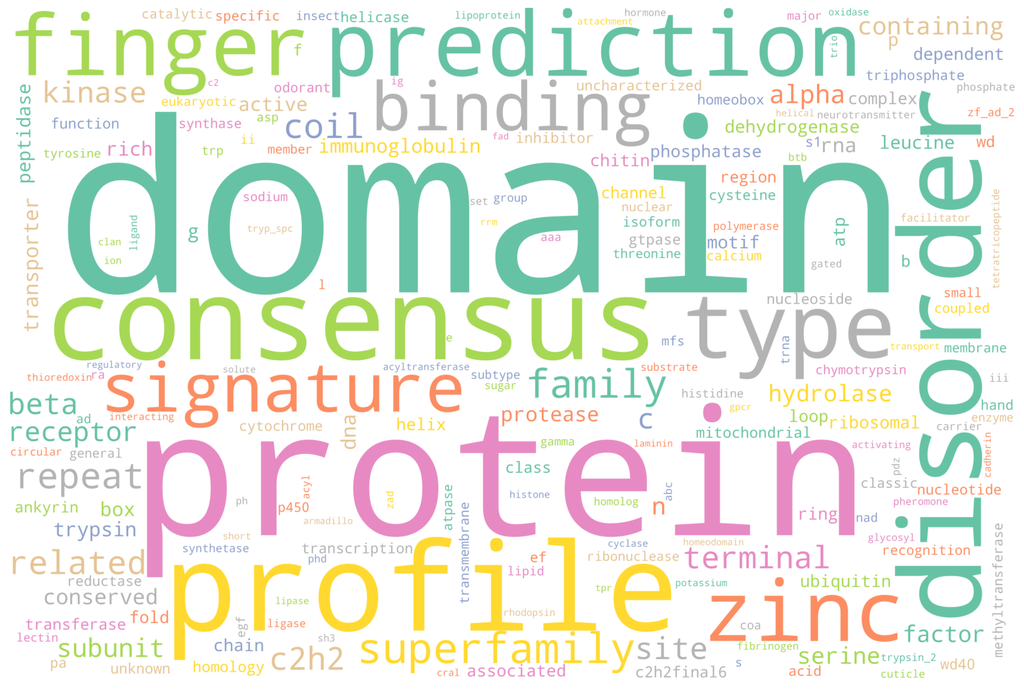

Back to top

## Part Two of This Project: The Sample Data

In total, 884 (442 pairs) Illumina Next-Generation Sequencing files were received. Each file under-went quality control and was aligned as a pair to the reference genome. To ensure and improve sample quality, each file was run through:

- Trimmomatic to trim the reads  
- FastQC to evaluate the data visually and quickly

To align the paired-end reads to the reference genome, each pair of files were run through:

- BWA mem algorithm to perform a local alignment (due to its high speed and accuracy) both pre and post reference genome masking

### Trimming Illumina Paired-end Data Using Trimmomatic

The 884 (442 pairs) Illumina NGS files used for this project were received in gzipped * .fastq format. The data consisted of paired-end files, with each pair having the same basename and ending in either *1 or* 2. Each pair of files have the same number of sequences and sequence order. In order to properly clean up the data, a program called Trimmomatic [[10]](http://www.usadellab.org/cms/?page=trimmomatic) was used due to it being able to correctly handle paired end reads.

Trimmomatic is a flexible read trimming tool for Illumina NGS data that can remove low quality regions and reads, as well as generic, specific adapter sequences. The options used for the purposes of this project are:

- SLIDINGWINDOW: Perform a sliding window trimming, cutting once the average quality within the window falls below a threshold.
- MINLEN: Drop the read if it is below a specified length.
- LEADING: Cut bases off the start of a read, if below a threshold quality.
- TRAILING: Cut bases off the end of a read, if below a threshold quality.

The SLIDINGWINDOW parameter used the typical 4-base wide window and cut when the average quality dropped below 15 in order to filter out low quality reads. The LEADING and TRAILING parameters were used due to the majority of the data files showing issues in the beginnings and ends of the reads after FastQC was run on the raw files. After running Trimmomatic, most read issues were resolved. Trimmomatic version 0.38 was used.

```python
%%script bash --bg

module unload trimmomatic/0.39
module load trimmomatic/0.38

for infile in /projects/cooper_research1/Culex_WGS/trimm_files/*_1.fq.gz
do
        base=$(basename ${infile} _1.fq.gz)
        PEfile=${base}_1.PE.fq.gz
        PEfile2=${base}_2.PE.fq.gz
        if [ -e "$PEfile" ] && [ -e "$PEfile2" ]
                then
                        echo "${base} is okay"
                else
                        java -jar Trimmomatic-0.38.jar PE ${infile} ${base}_2.fq.gz \
                        ${base}_1.PE.fq.gz ${base}_1.SE.fq.gz \
                        ${base}_2.PE.fq.gz ${base}_2.SE.fq.gz \
                        SLIDINGWINDOW:4:15 MINLEN:36 LEADING:3 TRAILING:20
        fi
done
```

### Quality Control With FastQC

FastQC [[11]](https://www.bioinformatics.babraham.ac.uk/projects/fastqc/) is a quality control tool created for high throughput sequence data that aims to execute quality control checks on raw sequences from sequencing pipelines. In order to quickly analyze potential problems with the data before completing further analysis, running FastQC allows the user to check sequence length, GC content, sequences flagged as poor quality, and a graph of per base sequence quality.

After running FastQC on the raw reads separately, it was found that the majority of the data files showed issues in the beginning and ends of the reads, leading to the decision to include LEADING and TRAILING parameters during the Trimmomatic step. After taking care of this issues using Trimmomatic, the FastQC outputs mirrored good Illumina data. FastQC version 0.11.9 was used.

The main functions of FastQC are:

- Import of data from BAM, SAM or FastQ files (any variant)
- Providing a quick overview to tell you in which areas there may be problems
- Summary graphs and tables to quickly assess your data
- Export of results to an HTML based permanent report
- Offline operation to allow automated generation of reports without running the interactive application

```python
%%script bash --bg

module load fastqc

### For running fastqc on raw files + post-trimmed paired-end files
fastqc *.fq.gz
### For running fastqc on just post-trimmed paired-end files
fastqc *.PE.fq.gz

### Another method:
for infile in /projects/cooper_research1/Culex_WGS/trimm_files/*.fq.gz
do
        fastqc ${infile}
done
### -----------------------------------------------------------------
for infile in /projects/cooper_research1/Culex_WGS/*.fq.gz
do
        fastqc ${infile}
done
```

#### FastQC Tool

Sample file 's_14I_CSFP200003410-1a_H3LKHDSXY_L2_1'.

Raw File

Trimmed File

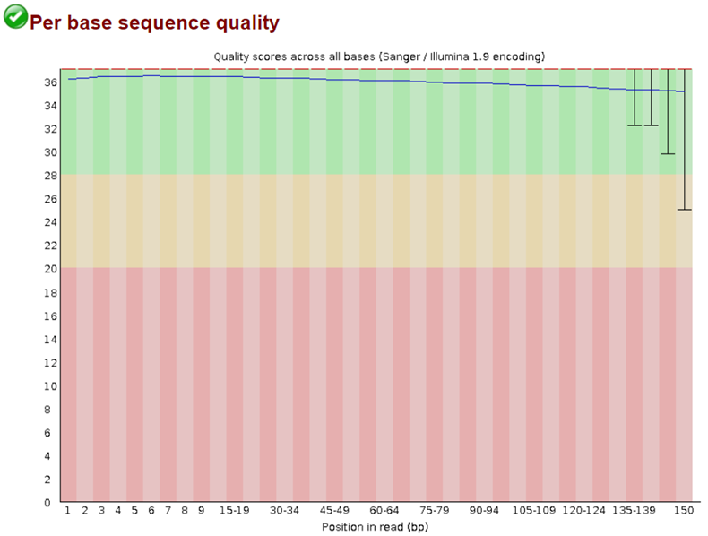

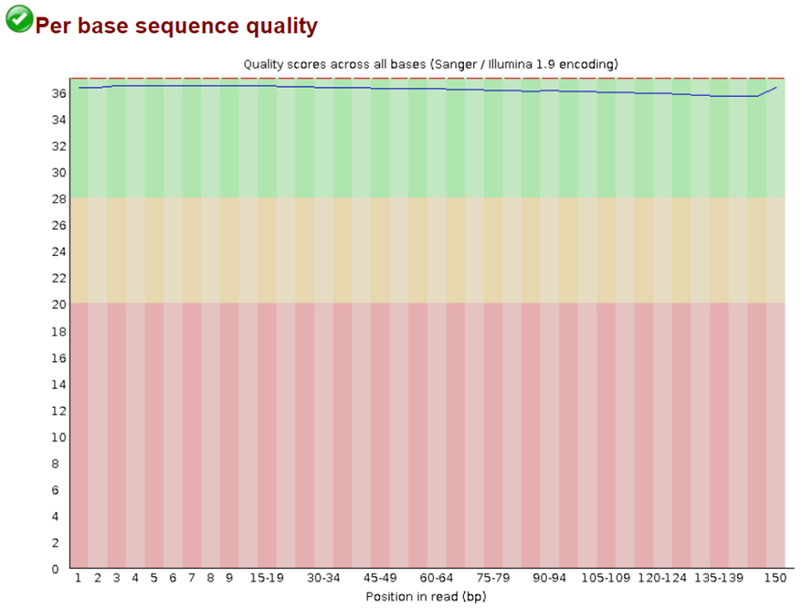

-

-

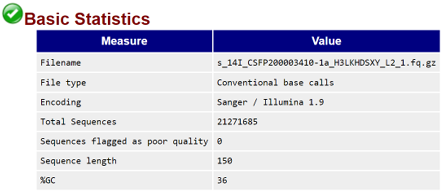

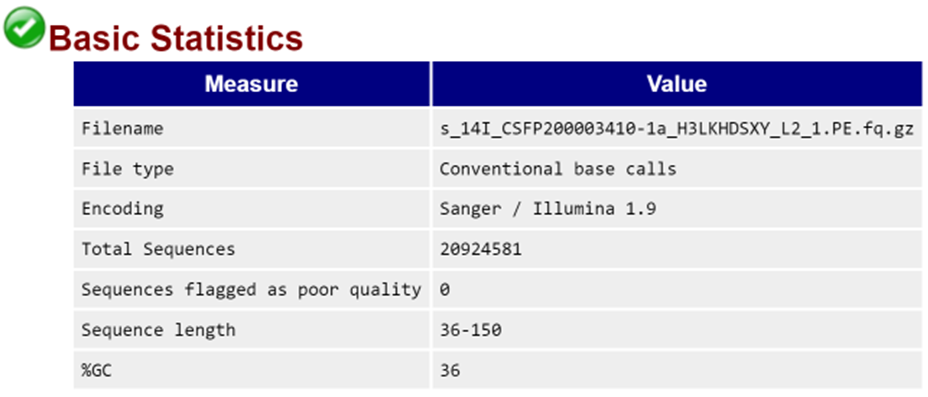

### Local Alignment With BWA-MEM

In order to map low-divergent sequences against a reference genome, the Burrows-Wheeler Alignment Tool package was used. This tool consists of three algorithms: BWA-backtrack, BWA-SW and, the one used for this project, BWA-MEM [[12]](http://bio-bwa.sourceforge.net/bwa.shtml). The BWA mem algorithm performs local alignment and was designed for Illumina sequence reads ranging from from 70bp to 1Mbp and is suggested for high-quality queries due to its high speed and accuracy. BWA version 0.7.17 was used.

For the purposes of this project, only one flag was used, -t, referring to the use of 16 threads. Each pair of files was aligned against the UC Davis C. tarsalis genome.

```python
%%script bash --bg

module load bwa

bwa index Culex-tarsalis_knwr_CONTIGS_CtarK1.fa

for infile in /projects/cooper_research1/Culex_WGS/trimm_files/*_1.PE.fq.gz
do
        base=$(basename ${infile} _1.PE.fq.gz)
        PEfile=${base}.sam
        if [ -e "$PEfile" ]
                then
                        echo "${base} is okay"
                else
                        echo "${base} starting processing"
                        bwa mem -t 16 Culex-tarsalis_knwr_CONTIGS_CtarK1.fa ${infile} ./${base}_2.PE.fq.gz > ${base}.sam
        fi
done
```

### Alignment Statistics and Format Conversion With Samtools

Samtools [[13]](http://www.htslib.org/doc/samtools-view.html) is a program for reading, writing, editing, indexing, and viewing high-throughput sequencing data in SAM, BAM, and CRAM format. The samtools view command in particular views and converts SAM, BAM, and CRAM files. Samtools version 1.10 was used.

In order to see alignment statistics for this project, flags -c, -F and -q were used. Flag option -c counts the number of reads in the file, whereas option -c -F 4 counts the number of mapped reads in the file. Option -c -F 4 -q allows for the specification of quality for the counted reads mapped. Both -q 20 and -q 10 were calculated.

```python
%%script bash --bg

module load samtools

echo "File" >> names.txt
echo "Total_#_Alignments" >> read_counts.txt
echo "#_Mapped" >> mapped_read_counts.txt
echo "Q20_#_Mapped" >> Q20_mapped_read_counts.txt
echo "Q10_#_Mapped" >> Q10_mapped_read_counts.txt

for infile in ./*.bam
do
    base=$(basename ${infile} .sam)

    # To get file name
    echo ${base} >> names.txt

    # To get total read count
    samtools view -c ${infile} >> read_counts.txt

    # To get mapped read count
    samtools view -c -F 4 ${infile} >> mapped_read_counts.txt

    # To get mapped read count for reads with a quality of 20 or higher
    samtools view -c -F 4 -q 20 ${infile} >> Q20_mapped_read_counts.txt

    # To get mapped read count for reads with a quality of 10 or higher
    samtools view -c -F 4 -q 10 ${infile} >> Q10_mapped_read_counts.txt

paste names.txt read_counts.txt mapped_read_counts.txt Q20_mapped_read_counts.txt Q10_mapped_read_counts.txt
>> counts.txt | column -s $'\t' -t >> counts_table.txt
```

After these files were aligned using BWA mem and their statistics were examined, it was discovered that, though an average of 84.53% of reads were mapped per file, the quality of the reads were poor. Only an average of 36.64% of reads mapped had a quality of 20 or higher amongst the files, and an average of 42.74% of reads mapped had a quality of 10 or higher. Due to 56 of the sequences having an extremely low mapping percentage, only 386 files were kept for the remainder of the project.

#### Number Of Reads Pre-Masking

Reads count post-BWA mem on trimmed paired-end FASTQ files (aligned to unmasked reference genome)

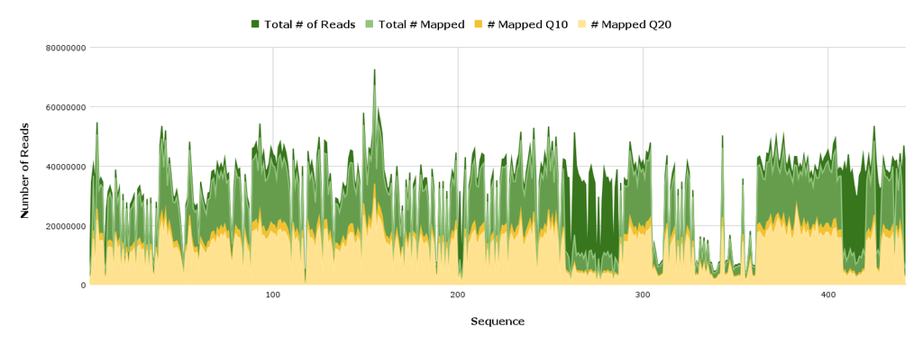

The Burrows-Wheeler Alignment Tool package was used again, using the same code format as presented earlier, with the substitution of the masked genome rather than the raw UC Davis C. tarsalis genome.

#### Number Of Reads Post-Masking

Reads count post-BWA mem on trimmed paired-end FASTQ files (aligned to masked reference genome)

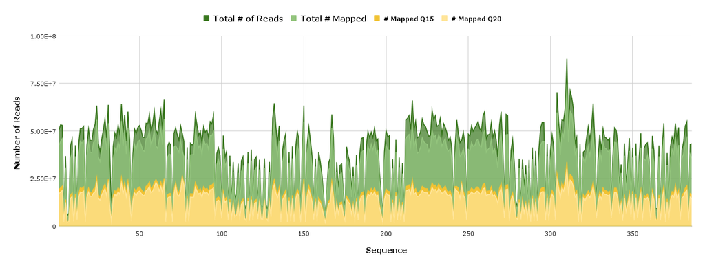

### Failed Trials: Alternative Mapping With Stampy

Due to low read quality, Stampy [[14]](https://github.com/uwb-linux/stampy), an alternative package for mapping short Illumina sequencing reads to a reference genome, was utilized. The program requires the use of BWA mem, a step already completed, and needed the resulting SAM files to be converted to BAM files using samtools view. Stampy version 1.0.29 was used.

The following features are posted on the Stampy GitHib:

- Maps single, paired-end, mate pair Illumina reads to a reference
- Fast: about 10 (with BWA) or 15 hours (without) per Gbase
- Low memory footprint: 2.7 Gb shared memory for a 3Gbase genome
- High sensitivity for indels and divergent reads, up to 10-15%
- Low mapping bias for reads with SNPs or indels
- Well calibrated mapping quality scores
- Strips adapters to improve miRNA read mapping
- Input: Fastq and Fasta; gzipped or plain; SAM and BAM
- Output: SAM, Maq's map file
- Optionally calculates per-base alignment posteriors
- Optionally processes part of the input
- Handles reads up to 4500 bases

After these files were aligned using BWA mem and stampy and their statistics were examined, it was discovered that, the average of reads that were mapped per file was just as low as when only BWA mem had been used, and the quality of the reads were still poor.

```python
%%script bash --bg

module load samtools

samtools view -S -b ${infile} > ${base}.bam

python2.7 ./stampy-1.0.29/stampy.py -g ./culex_genome -h ./culex_genome -t8 --bamkeepgoodreads -M 'stampy_aln-PE-${base}.bam
```

Back to top